# Programming Assignment 1 - Chatbot Eliza

**Group 1:** Zack, Charles, Jay, Maryah, Ray  
**AIT 526**  
**Programming Assignment 1**

## Introduction

**Problem Statement**  
The purpose of this program is to create a chatbot named Eliza which can function in the role of a Rogerian psychotherapist. Eliza doesn't need to know anything about the real world as Rogerian psychotherapists simply ask questions that encourage the patient to look inward. Eliza must have the capability to recognize key words and respond in syntactically correct English based on the input from the user.  
**User Guide**  
Execute our Eliza program by first installing a virtual environment and selecting it as the Jupyter Notebook kernel per step 0 below, and then running all notebook cells in order.  
Eliza will prompt you for your name, and then converse with you as if she is a Rogerian Psychotherapist. When you are done speaking with her, just let her know in clear terms and she will terminate the conversation. For example, tell her "thank you and goodbye until next week" and she will wish you well and end the program.  
A conversation with our Eliza may look like the following:

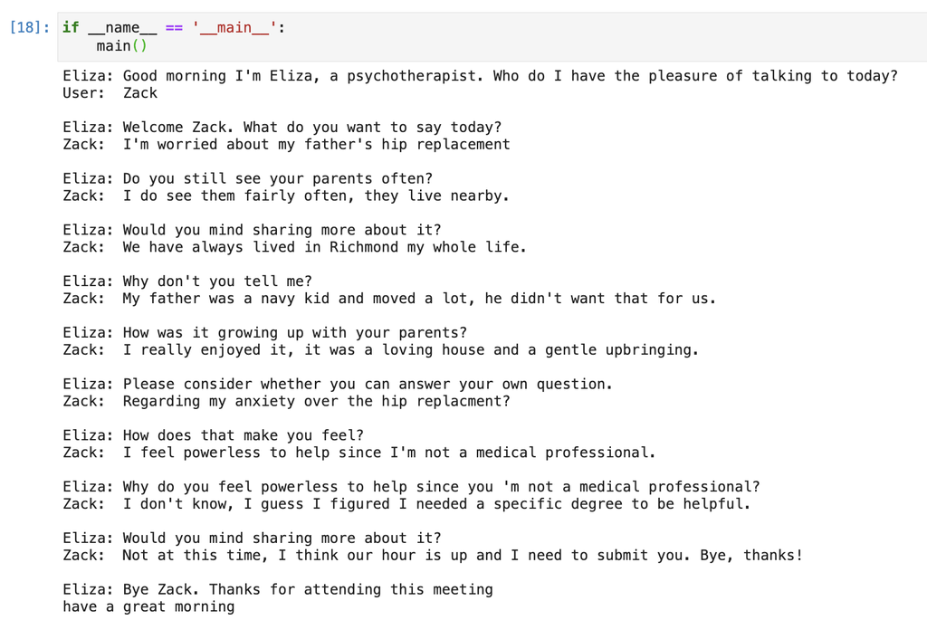

**Algorithm Design**

1. Request and save off the user's name for use throughout the conversation.
2. Ask the user what they would like to talk about.
3. Unless an "end" word is contained within the user's response, reply with a question based on the user's input. "Bye" and "exit" are examples of "end" words. If an "end" word is supplied, terminate the conversation and program.
4. To form the response, attempt to pattern match the user's input with a predefined static data dictionary of keywords and canned responses. Swap 1st/2nd POV pronouns found in the user's input when recycling it as part of Eliza's response by using a pronoun specific data dictionary to search for 1st/2nd POV pronouns in the user input.
5. Continue collecting user input and responding according to the data dictionaries until an "end" word is detected in the user input, then terminate.

## 0. Virtual environment setup

**A) Open a terminal and execute the following commands**

```
conda create -y -n eliza_env python=3.9 nltk ipykernel
conda activate eliza_env
python -m ipykernel install --user --name=eliza_env
```

**B) Select `eliza_env` from the kernel dropdown in Jupyter Notebook**

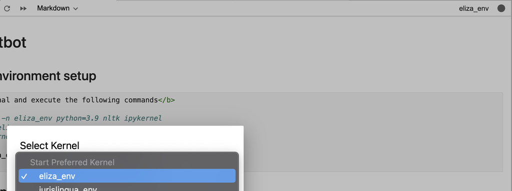

## 1. Imports

```python
import re
import datetime
import random
from nltk.tokenize import word_tokenize
import json
```

## 2. Data dictionaries to help Eliza form responses

### 2.1 Data dictionary of responses and keywords with regex

```python
# Keywords and canned responses that may or may not use some of the user input
data_dictionary = {
    'I need (.*)' : [
        'Why do you need %s?',
        'Would it really help you to get %s?',
        'Are you sure you need %s?'
    ],
    'I feel (.*)' :[
        'Why do you feel %s?',
        'Why do you think that is?',
        'What else do you feel?',
        'I hear that you that you are feeling like %s, how do you think I can help you?'
    ],
    'I like (.*)' : [
        'Do you think %s is a good thing to like?',
        'Why do you like %s?',
        'How long have you liked %s?',
        'How did you come to like %s?'
    ],
    '(.*)parent|mom|mother|dad|father|daddy|mommy(.*)' :[
        "Tell me more about your childhood.",
        "How was it growing up with your parents?",
        "Do you still see your parents often?"
    ],
    "Why don\\'?t you ([^\\?]*)\\??" : [
        "Do you really think I don't %s?",
        "Perhaps eventually I will %s."
    ],
    "I am (.*)" : [
        "Did you come to me because you are %s",
        "How long have you been %s?",
        "How do you feel about being %s?"
    ],
    "I\\'?m (.*)" : [
        "How does being %s make you feel?",
        "Do you enjoy being %s?"
    ],
    "I would (.*)" : [
        'Could you explain why you would %s?',
        'Why would you %s?',
        'Who else knows that you would %s?'
    ],
    "Is there (.*)" : [
        "Do you think there is %s?",
        "It's likely that there is %s",
        "Would you like there to be %s?"
    ],
    "I (can\\'t|cannot) (.*)" : [
        "Did you at least try %s",
        "What do you think you can do to prepare for %s?"
    ],
    # Seems easy enough to turn around an "I don't want" statement by being vague.
    "I don\\'?t? want(.*)" : [
        "Have you ever wanted %s?",
        "Is there a reason wy you don't want %s?",
        "Do you want something else?",
        "What do you want now then?"
    ],
    "(.*)forever(.*)" : [
        "Forever is a long time.",
        "That sounds endless, tell me how you feel about it?"
    ],
    # Responses assume the user is getting divorced. Could make more robust.
    "(.*)divorce(.*)" : [
        "Are you sure about pursuing this choice?",
        "What happened?",
        "Have you talked to your partner about this choice?"
    ],
    # When the user includes elipses
    "(.*)\.{3}|\u2026" : [
        "Are you uncertain of what you're saying?",
        "I'm"+' sorry, am I misunderstanding what "%s" means?',
        "Ahh yes that is very interesting. What other thoughts does that provoke?"
    ],
    # The catch-all for any user statements that don't match patterns above or contain an end word
    "(.*)" : [
        "Can you tell me more about it?",
        "I see.",
        "Very interesting",
        "Why don't you tell me?",
        "Would you mind sharing more about it?",
        "Please tell me more.",
        "Why do you ask that?",
        "Please consider whether you can answer your own question.",
        "Perhaps the answer lies within yourself.",
        "How does that make you feel?",
        "I would like to hear more about this.",
        "Have you talked to anyone about this?"
    ],
}
```

### 2.2 Data dicitonary of pronoun replacements for switching between 1st and 2nd POV

```python
# Pronoun dictionary
pronoun_dict = {
    "you" : "me",
    "me" : "you",
    "yours" : "mine",
    "mine" : "yours",
    "your" : "my",
    "my" : "your",
    "you will" : "I will",
    "I will" : "you will",
    "you have" : "I have",
    "I have" : "you have",
    "you can" : "I can",
    "I can" : "you can",
    "am" : "are",
    "are" : "am",
    "was" : "were",
    "were" : "was",
    "i" : "you",
    "you" : "i",
    "i'd" : "you would",
    "i've" : "you have",
    "i'll" : "you will",
    "you've" : "I have",
    "you'll" : "I will"
}
```

### 2.3 Example: saving data dictionaries to static json files

```python
# In case we want to save to json file
f = open("data.json", 'w')
json.dump(data_dictionary, f)
f.close()
```

```python
# and load from json file
with open('data.json', 'r') as fp:
    dic = json.load(fp)
```

## 3. Eliza functionality

```python
# Pronoun replacement for better, more realisticly formed responses
def replace_pronouns(match):
    """ Substitute pronouns to turn 2nd pov into 1st pov and 1st pov into 2nd pov, vice versa """
    tokenizer = word_tokenize(match)

    for x, token in enumerate(tokenizer):
        if token in pronoun_dict:
            tokenizer[x] = pronoun_dict[token]
    return ' '.join(tokenizer)

# Better function name might be get_eliza_response
def get_input(user_input, data_dictionary=dic):
    """ Returns Eliza's response to user input. """
    for pattern, responses in data_dictionary.items():
        # Check for matching input v. key
        ans = re.search(pattern.lower(), user_input.rstrip(",.!"))

        # if the key matches the input, returns (prints) the "response"
        if ans:
            # Randomly choose a valid response
            response = random.choice(responses)

            # If we need to rephrase part of the question in the output
            if "%s" in response:
                match = ans[1]
                # when and if the key word contains 2nd or 1st person pov, transform
                # and vice versa
                response = response % (replace_pronouns(match))
                return response
            else:
                return response

def handle(user_name):
    """ Main engine of the chat bots. Verify the username entered and resend the greeting """
    print("Eliza: Welcome %s. What do you want to say today?" % user_name)
    # standard expression for bye
    end = [r'.*quit.*', r'.*bye.*', r'.*exit.*']
    user_continue = True
    while user_continue:
        # check and get input name and information
        user_input = input('%s: ' % user_name)
        print()
        # convert input into lowercase
        user_input = user_input.lower()

        # check for 'end' input such as 'bye' or 'exit'
        for i in end:
            user_exit = re.findall(i, user_input)
            # if there is an "end" input, exit the while loop
            if len(user_exit) != 0:
                user_continue = False
        # If there is no "end" input, continue and return an appropriate response
        if user_continue:
            response = get_input(user_input)
            print("Eliza: " + response)

def greeting():
    """ Additional features for greeting at the correct time: morning, noon, evening """
    current_time = datetime.datetime.now()
    if current_time.hour < 12:
        return "Good morning"
    elif 12 <= current_time.hour < 18:
        return "Good afternoon"
    else:
        return "Good evening"

def init_conversation():
    """ Start a dialog and respond by entering an additional function greeting ... """
    print("Eliza: %s I'm Eliza, a psychotherapist. Who do I have the pleasure of talking to today?" % greeting())

    name_input = input('User: ')
    print()

    tokenizer = word_tokenize(name_input.replace('.', ''))

    user_name = tokenizer[-1]
    return user_name

def ending():
    """ ability to end chats at the correct time """
    current_time = datetime.datetime.now()

    if current_time.hour < 12:
        return "great morning"
    elif 12 <= current_time.hour < 18:
        return "great afternoon"
    else:
        return "great evening"

def main():
    """ main function to start chat conversation. """
    user_name = init_conversation()
    handle(user_name)

    print(
        """Eliza: Bye %s. Thanks for attending this meeting\nhave a %s""" % (user_name, ending())
    )
```

## 4. "Therapy Session" with Eliza

```python
if __name__ == '__main__':
    main()
```